# 1 - Problem Statement and Its Importance

#### Problem Statement

The problem we are trying to solve is to be able to predict how well a college player will perform in the NBA.

#### Importance

Every year all 30 NBA teams participate in a 2 round NBA Draft. Where all 30 NBA teams normally get 2 picks in the draft, 1 in the first round and 1 in the second round for a total of 60 picks in the NBA Draft.

Most players selected in the NBA draft are college players who have had to play at least 1 season in college. But in the most recent NBA drafts, there has been an uptick in international players and high school players who elected to play professional basketball overseas or in the G-League (NBA minor league). The reason for this is play in the college basketball doesn't exactly translate to the NBA because of how different the style of play in college is to the NBA.

Being able to accurately predict performance in the NBA can go a long way for NBA general managers in a sense where they aren't wasting their 1 of 2 draft picks on a low potential player coming out of college. This goes into our problem statement where determining the performance of a college player in the NBA has become very unpredictable through the eyes. That's why I try to solve this problem using a machine learning model on college players career stats to predict their Wins Above Replacement (WAR) in the NBA.

# 2 - Background Knowledge

#### What is the NBA Draft?

The NBA Draft is an annual event that brings amateur basketball players and international players into the NBA. To qualify for the NBA draft in that given year, you have to meet a certain age-requirement (19 years of age) and must send in a letter of intent to the NBA office (Berger and Daumann). To meet that 19-years old age requirement, most players choose to go from high school to college for a minimum of 1 year or from high school to the NBA's minor league called the "G-League" for a year (NBA and NBPA 288). Otherwise, they are born and raised international players that play professional overseas until they hit the age requirement where they will then enter the NBA draft. Each NBA team has an opportunity to select two draftees, one in the first round and one in the second round (The NBA draft has a total of 2 rounds) at a select date when the NBA draft occurs.

Drafting a draftee basically means the NBA team that has the exclusive right to the draftees first NBA contract (Berger and Daumann). If the draftee intends to join the NBA, he then must sign with the team that has the exclusive rights to his first NBA contract (The team that drafted him) (Berger and Daumann).

The order of the NBA draft is determined by teams' success in the previous season. The winningest team will get the last pick in each round, the second best gets the 29th pick in each round, and so on (Berger and Daumann). Now the worst 14 teams enter what is called the NBA draft lottery.

#### What is the NBA Draft Lottery?

The NBA draft lottery is used to determine the first 14 picks of the NBA draft. Each of the worst 14 teams from last season is given a probability on how likely they will get the first overall pick. With the worst three teams last year having the same probability of getting the first overall pick, then the 4th worst team getting the 2nd best odds to get the first overall pick, and so on (NBA.com Staff).

The procedure of determining the order of the first 14 picks of the NBA draft go like this. Fourteen ping pong balls numbered 1 through 14 will be placed in a lottery machine (NBA.com Staff). Which means there is 1,001 possible combinations, 1,000 of those 1,001 combinations will be assigned to the 14 participating lottery teams (NBA.com Staff).

The purpose of the lottery is to prevent teams purposely losing to get the best overall pick in the NBA draft. Because if the draft order was the set that the worst team in the NBA is first overall pick and the best team is the last overall pick, then teams will begin to tank their season to get the first overall pick and a chance at a franchise player.

#### What is so Different between College and NBA Basketball?

Like mentioned before, college basketball and the NBA are two different versions of basketball. The nature of the game is different, for example, the speed of play is different. The NBA is played at a much faster pace than college basketball which would require players to adjust both mentally and physically to keep up (Bishop). Physicality is different, the NBA is much more physical, so players must improve their strength to compete against bigger and better competition (Bishop). Lastly the talent gap, in college it is not common that an "NBA-level" talent plays against "NBA-level" talent, whilst in the NBA is filled with the best players from around the world so they are constantly performing against the best (Bishop).

On top of that the style of play between the NBA and college basketball is different as well. The NBA is centered around complex schemes centered around pick-n-roll, isolation, off-ball movement, and often individual play where teams lean on their best players (Bishop). Whilst college is centered around team-oriented play and motion offense (Bishop). The shot selection is completely different as well. The NBA leans on three-pointers and points near the basket, whilst college leans on a wide-array of shots like layups, three-pointers, post play, and mid-range shots (Bishop).

Lastly, the roles of players on college teams compared to NBA teams are different. NBA is basically positionless, where we have seen 7-foot centers shoot three-point shots and are able to score near the basket (Bishop). While college players are assigned a very specific position and rarely deviate from it. Also in college, they can sometimes ask their star players to take a lesser role or a more team-friendly role, which can ultimately limit the players production (Bishop).

All these differences are key reasons on why it is so hard to predict NBA success from college players. The way the game is played between the two levels is very different. Which means players that dominate in college could struggle in the NBA and vise versa.

#### How do we Measure NBA Success? What is Wins Above Replacement (WAR)?

Now there are many ways to measure NBA success, like how many points a player is averaging per game, or assists per game, etc. But in the recent years there have been developments when it comes to advanced statistics in the NBA. One comes to mind in particular called Wins Above Replacement (WAR), which we will use as our outcome variable in this project.

The term Wins Above Replacement (WAR) is a concept that was originally developed in the Baseball realm. The statistic is used in basketball to quantify a player's value to their team compared to a theoretical replacement player. So, in the NBA, WAR aims to measure how many more wins a player contributes to theri team compared to an replacement-level player over the course of an 82 game season. In detail, WAR evaluates players in a context of a team made up of the certain player with four completely average players around him (Pelton). The performance of the team the player is on is then compared to that of a team made up of four average players and one "replacement-level" player (Pelton). So, this would mean a positive WAR results in the player contributing more than a "replacement level" player, whilst a negative WAR results in the player contributing below "replacement level", and a WAR value of 0 means the player contributed right at "replacement level".

What we deem as "replacement level" in the NBA is a rotational player who gets in the game here and there but isn't too relied on, he is just in the game to give the starters a break (Pelton).

# 3 - Importing the Data

We will be importing two datasets, one dataset contains our players/stats from the NBA and the other dataset contains the players/stats from college.

```python
import pandas as pd # Import Pandas Library
pd.options.mode.chained_assignment = None  # default='warn'
import numpy as np # Import Numpy Library
from matplotlib import pyplot as plt
import seaborn as sns

import warnings
warnings.filterwarnings("ignore")
```

```python
college_stats = pd.read_csv('Data/nba_players_college_stats.csv') # Import our dataset that has our college stats and players
nba_stats = pd.read_csv("Data/historical_RAPTOR_by_player.csv") # Import our dataset that has our nba stats and players
```

# 4 - Joining our Data

#### Working with our College Data

Our college dataset contains 10,123 and 28 columns, with data all the way back from the 1970s.

```python
college_stats.head() # View the head of our college stats data
```

|  | name | age | college_id | g | mp | fg | fga | fg3 | fg3a | ft | ... | pts | fg_pct | fg3_pct | ft_pct | mp_per_g | pts_per_g | trb_per_g | ast_per_g | player_html | season |
| --- | --- | --- | --- | --- | --- | --- | --- | --- | --- | --- | --- | --- | --- | --- | --- | --- | --- | --- | --- | --- | --- |
| 0 | Udoka Azubuike | 17 | KANSAS | 11.0 | 142.0 | 22.0 | 35.0 | 0.0 | 0.0 | 11.0 | ... | 55.0 | 0.629 | NaN | 0.379 | 12.9 | 5.0 | 4.4 | 0.2 | https://www.basketball-reference.com/players/a... | 2016-17 |
| 1 | Udoka Azubuike | 18 | KANSAS | 36.0 | 848.0 | 211.0 | 274.0 | 0.0 | 0.0 | 45.0 | ... | 467.0 | 0.770 | NaN | 0.413 | 23.6 | 13.0 | 7.0 | 0.7 | https://www.basketball-reference.com/players/a... | 2017-18 |
| 2 | Udoka Azubuike | 19 | KANSAS | 9.0 | 184.0 | 55.0 | 78.0 | 0.0 | 0.0 | 11.0 | ... | 121.0 | 0.705 | NaN | 0.344 | 20.4 | 13.4 | 6.8 | 0.6 | https://www.basketball-reference.com/players/a... | 2018-19 |
| 3 | Udoka Azubuike | 20 | KANSAS | 31.0 | 859.0 | 181.0 | 242.0 | 0.0 | 0.0 | 64.0 | ... | 426.0 | 0.748 | NaN | 0.441 | 27.7 | 13.7 | 10.5 | 0.9 | https://www.basketball-reference.com/players/a... | 2019-20 |
| 4 | Marty Byrnes | 18 | SYRACUSE | 19.0 | NaN | 6.0 | 15.0 | NaN | NaN | 6.0 | ... | 18.0 | 0.400 | NaN | 0.500 | NaN | 0.9 | 1.4 | 0.0 | https://www.basketball-reference.com/players/b... | 1974-75 |

5 rows × 28 columns

```python
# The college stats is not a totals dataset, each row represents and player and a season.
# So we have to groupby a unique variable which will be our column 'player_html" and take the sum or mean of each column to get career totals/averages
college = college_stats.groupby(['player_html'], as_index=False).agg({
    'name':'last',
    'age':'last',
    'college_id':'last',
    'g':'sum',
    'mp':'sum',
    'fg':'sum',
    'fga':'sum',
    'fg3':'sum',
    'fg3a':'sum',
    'ft':'sum',
    'fta':'sum',
    'orb':'sum',
    'trb':'sum',
    'ast':'sum',
    'stl':'sum',
    'blk':'mean',
    'tov':'sum',
    'pf':'sum',
    'pts':'sum',
    'season':'last',
})

# Create some new columns, these are going to be shooting percentages and per game statistics
college['fg_perc'] = college['fg'] / college['fga']
college['fg_game'] = college['fg'] / college['g']
college['fga_game'] = college['fga'] / college['g']
college['fg3_perc'] = college['fg3'] / college['fg3a']
college['ft_perc'] = college['ft'] / college['fta']
college['orb_game'] = college['orb'] / college['g']
college['trb_game'] = college['trb'] / college['g']
college['ast_game'] = college['ast'] / college['g']
college['stl_game'] = college['stl'] / college['g']
college['blk_game'] = college['blk'] / college['g']
college['tov_game'] = college['tov'] / college['g']
college['pf_game'] = college['pf'] / college['g']
college['pts_game'] = college['pts'] / college['g']
college['mp_game'] = college['mp']/college['g']
college['fta_game'] = college['fta']/college['g']
college['ft_game'] = college['ft']/college['g']
college['fg3_game'] = college['fg3']/college['g']
college['fg3a_game'] = college['fg3a']/college['g']

# Create a column that contains the final season that player was in college for.
college['end_season'] = college['season'].str.split("-", n=1).str[0]
college['end_season'] = pd.to_numeric(college['end_season']) # Change column from string to numeric
```

We will be only wanting players from 1980 and above. The reason for this is because starting in 1980 is when all the players have all their college and NBA stats filled.

```python
college = college[college['end_season'] >= 1980] # Only want players from past 40 years
```

#### Working with our NBA Data

The NBA dataset contains 18,553 rows and 15 columns. This dataset contains NBA players advanced stats in the NBA by season.

```python
nba_stats.head() # View our NBA stats dataset
```

|  | player_name | player_id | season | poss | mp | raptor_offense | raptor_defense | raptor_total | war_total | war_reg_season | war_playoffs | predator_offense | predator_defense | predator_total | pace_impact |
| --- | --- | --- | --- | --- | --- | --- | --- | --- | --- | --- | --- | --- | --- | --- | --- |
| 0 | Alaa Abdelnaby | abdelal01 | 1991 | 640 | 303 | -3.938450 | -0.510076 | -4.448526 | -0.265191 | -0.226163 | -0.039028 | -3.905732 | -1.696796 | -5.602528 | 0.199241 |
| 1 | Alaa Abdelnaby | abdelal01 | 1992 | 1998 | 959 | -2.553849 | -0.197943 | -2.751792 | -0.006893 | 0.070322 | -0.077215 | -2.499576 | -0.721876 | -3.221452 | 0.485436 |
| 2 | Alaa Abdelnaby | abdelal01 | 1993 | 2754 | 1379 | -2.373736 | -2.069808 | -4.443544 | -1.227189 | -0.845272 | -0.381918 | -2.328144 | -2.002263 | -4.330407 | 0.488266 |
| 3 | Alaa Abdelnaby | abdelal01 | 1994 | 320 | 159 | -6.140056 | -2.748312 | -8.888368 | -0.500600 | -0.500600 | 0.000000 | -5.820936 | -3.526560 | -9.347496 | 0.511152 |
| 4 | Alaa Abdelnaby | abdelal01 | 1995 | 984 | 506 | -3.846543 | -1.268012 | -5.114556 | -0.615802 | -0.615802 | 0.000000 | -3.715429 | -1.027024 | -4.742453 | 1.545922 |

#### Splitting Data into Decades

A big thing about basketball and the NBA is that it is always evolving. Meaning the style of basketball played in the 1980s is not the same as in the 2010s. Given this, we will split the data into decades, with a 1980s decade, 1990s decade, 2000s decade, and a 2010s+ where our most recent NBA data we have is from the year 2021. Technically we will be analyzing the changes in the game of basketball throughout the years, then we will be shifting our focus on players that played in the 2010s and creating models based on that data since it is the most recent decade and resembles more accurate style of play.

```python
# Function that creates our decade column
def create_decade(row):
    if row['season'] < 1980:
        val = 'Other'
    elif row['season'] < 1990:
        val = '1980s'
    elif row['season'] < 2000:
        val = '1990s'
    elif row['season'] < 2010:
        val = '2000s'
    else:
        val = '2010s+'
    return val

nba_stats['decade'] = nba_stats.apply(create_decade, axis=1) # Create new decade column
```

This dataset contains NBA players advanced stats in the NBA by season, so we will need to average their season stats together for each player. We will use the Wins Above Replacement (WAR) to be our predictor variable. The unique identifier is 'player_id' column which we can take to create the 'player_html' link seen in the college dataset. Another thing to note is that we will also be grouping by decade, so players might show up multiple times in the dataset but their numbers will correspond to their decade they played in.

```python
# Create the 'player_html' column that is in the college dataset using the unique identifier in the nba dataset called 'player_id'
nba_stats['player_html'] = "https://www.basketball-reference.com/players/" + nba_stats['player_id'].str[0] + "/" + nba_stats['player_id'] + ".html"

# The NBA stats is not a totals dataset, each row represents and player and a season.
# So we have to groupby a unique variable which will be our column 'player_id" and take the sum or mean of each column to get career totals/averages
nba = nba_stats.groupby(['player_id', 'decade'], as_index=False).agg({
    'player_html':'last',
    'mp':'sum',
    'war_total':'mean',
})

# Rename all the stat columns in the NBA dataset to add the suffix '_NBA' so we don't get confused with the stats when we merge
nba = nba.rename(columns={c: c+'_NBA' for c in nba.columns if c not in ['player_id', 'player_html']})
```

#### Combining our NBA and College Dataset

```python
final_df = pd.merge(college, nba, on="player_html", how='left') # Merge both datasets on "player_html"
```

```python
final_df[final_df['name'] == "Michael Jordan"] # View our dataset so far
```

|  | player_html | name | age | college_id | g | mp | fg | fga | fg3 | fg3a | ft | fta | orb | trb | ast | stl | blk | tov | pf | pts | season | fg_perc | fg_game | fga_game | fg3_perc | ft_perc | orb_game | trb_game | ast_game | … |
| --- | --- | --- | --- | --- | --- | --- | --- | --- | --- | --- | --- | --- | --- | --- | --- | --- | --- | --- | --- | --- | --- | --- | --- | --- | --- | --- | --- | --- | --- | --- |
| 1751 | https://www.basketball-reference.com/players/j... | Michael Jordan | 20 | UNC | 101.0 | 3107.0 | 720.0 | 1333.0 | 34.0 | 76.0 | 314.0 | 420.0 | 0.0 | 509.0 | 181.0 | 169.0 | 23.666667 | 200.0 | 271.0 | 1788.0 | 1983-84 | 0.540135 | 7.128713 | 13.19802 | 0.447368 | 0.747619 | 0.0 | 5.039604 | 1.792079 | … |
| 1752 | https://www.basketball-reference.com/players/j... | Michael Jordan | 20 | UNC | 101.0 | 3107.0 | 720.0 | 1333.0 | 34.0 | 76.0 | 314.0 | 420.0 | 0.0 | 509.0 | 181.0 | 169.0 | 23.666667 | 200.0 | 271.0 | 1788.0 | 1983-84 | 0.540135 | 7.128713 | 13.19802 | 0.447368 | 0.747619 | 0.0 | 5.039604 | 1.792079 | … |
| 1753 | https://www.basketball-reference.com/players/j... | Michael Jordan | 20 | UNC | 101.0 | 3107.0 | 720.0 | 1333.0 | 34.0 | 76.0 | 314.0 | 420.0 | 0.0 | 509.0 | 181.0 | 169.0 | 23.666667 | 200.0 | 271.0 | 1788.0 | 1983-84 | 0.540135 | 7.128713 | 13.19802 | 0.447368 | 0.747619 | 0.0 | 5.039604 | 1.792079 | … |

# 5 - Data Preparation

#### Taking Care of NAs

```python
final_df.columns[final_df.isna().any()].tolist() # View Columns that have NA Values
```

```
['blk',
 'fg_perc',
 'fg3_perc',
 'ft_perc',
 'blk_game',
 'player_id',
 'decade_NBA',
 'mp_NBA',
 'war_total_NBA']
```

We have nine columns that contain NA Values, lets inspect these columns to figure out what to do with these NA values.

```python
pd.set_option('display.max_columns', None)
pd.set_option('display.max_rows', 10)
final_df[final_df['fg3_perc'].isna()].head(5)
```

|  | player_html | name | age | college_id | g | mp | fg | fga | fg3 | fg3a | ft | fta | orb | trb | ast | stl | blk | tov | pf | pts | season | fg_perc | fg_game | fga_game | fg3_perc | ft_perc | orb_game | trb_game | ast_game | … |
| --- | --- | --- | --- | --- | --- | --- | --- | --- | --- | --- | --- | --- | --- | --- | --- | --- | --- | --- | --- | --- | --- | --- | --- | --- | --- | --- | --- | --- | --- | --- |
| 0 | https://www.basketball-reference.com/players/a... | Alaa Abdelnaby | 21 | DUKE | 134.0 | 1989.0 | 448.0 | 748.0 | 0.0 | 0.0 | 241.0 | 331.0 | 0.0 | 494.0 | 47.0 | 50.0 | 17.5 | 140.0 | 276.0 | 1137.0 | 1989-90 | 0.598930 | 3.343284 | 5.582090 | NaN | 0.728097 | 0.0 | 3.686567 | 0.350746 | … |
| 9 | https://www.basketball-reference.com/players/a... | Mark Acres | 22 | ORALROB | 110.0 | 3668.0 | 799.0 | 1416.0 | 0.0 | 0.0 | 440.0 | 632.0 | 0.0 | 1051.0 | 219.0 | 150.0 | 41.0 | 283.0 | 395.0 | 2038.0 | 1984-85 | 0.564266 | 7.263636 | 12.872727 | NaN | 0.696203 | 0.0 | 9.554545 | 1.990909 | … |
| 10 | https://www.basketball-reference.com/players/a... | Mark Acres | 22 | ORALROB | 110.0 | 3668.0 | 799.0 | 1416.0 | 0.0 | 0.0 | 440.0 | 632.0 | 0.0 | 1051.0 | 219.0 | 150.0 | 41.0 | 283.0 | 395.0 | 2038.0 | 1984-85 | 0.564266 | 7.263636 | 12.872727 | NaN | 0.696203 | 0.0 | 9.554545 | 1.990909 | … |
| 15 | https://www.basketball-reference.com/players/a... | Michael Adams | 22 | BOSTONCOLL | 119.0 | 3524.0 | 634.0 | 1350.0 | 0.0 | 0.0 | 382.0 | 509.0 | 0.0 | 320.0 | 475.0 | 275.0 | 3.0 | 335.0 | 241.0 | 1650.0 | 1984-85 | 0.469630 | 5.327731 | 11.344538 | NaN | 0.750491 | 0.0 | 2.689076 | 3.991597 | … |
| 16 | https://www.basketball-reference.com/players/a... | Michael Adams | 22 | BOSTONCOLL | 119.0 | 3524.0 | 634.0 | 1350.0 | 0.0 | 0.0 | 382.0 | 509.0 | 0.0 | 320.0 | 475.0 | 275.0 | 3.0 | 335.0 | 241.0 | 1650.0 | 1984-85 | 0.469630 | 5.327731 | 11.344538 | NaN | 0.750491 | 0.0 | 2.689076 | 3.991597 | … |

```python
final_df[final_df['blk'].isna()].head(5)
```

|  | player_html | name | age | college_id | g | mp | fg | fga | fg3 | fg3a | ft | fta | orb | trb | ast | stl | blk | tov | pf | pts | season | fg_perc | fg_game | fga_game | fg3_perc | ft_perc | orb_game | trb_game | ast_game | … |
| --- | --- | --- | --- | --- | --- | --- | --- | --- | --- | --- | --- | --- | --- | --- | --- | --- | --- | --- | --- | --- | --- | --- | --- | --- | --- | --- | --- | --- | --- | --- |
| 87 | https://www.basketball-reference.com/players/a... | Chris Andersen | 19 | BLINNTX | 29.0 | 628.0 | 108.0 | 214.0 | 6.0 | 25.0 | 70.0 | 133.0 | 0.0 | 224.0 | 20.0 | 0.0 | NaN | 0.0 | 0.0 | 292.0 | 1997-98 | 0.504673 | 3.724138 | 7.379310 | 0.24000 | 0.526316 | 0.0 | 7.724138 | 0.689655 | … |
| 88 | https://www.basketball-reference.com/players/a... | Chris Andersen | 19 | BLINNTX | 29.0 | 628.0 | 108.0 | 214.0 | 6.0 | 25.0 | 70.0 | 133.0 | 0.0 | 224.0 | 20.0 | 0.0 | NaN | 0.0 | 0.0 | 292.0 | 1997-98 | 0.504673 | 3.724138 | 7.379310 | 0.24000 | 0.526316 | 0.0 | 7.724138 | 0.689655 | … |
| 137 | https://www.basketball-reference.com/players/a... | Darrell Armstrong | 22 | FAYETVILST | 78.0 | 2105.0 | 373.0 | 723.0 | 75.0 | 187.0 | 291.0 | 374.0 | 0.0 | 306.0 | 296.0 | 0.0 | NaN | 0.0 | 0.0 | 1112.0 | 1990-91 | 0.515906 | 4.782051 | 9.269231 | 0.40107 | 0.778075 | 0.0 | 3.923077 | 3.794872 | … |
| 138 | https://www.basketball-reference.com/players/a... | Darrell Armstrong | 22 | FAYETVILST | 78.0 | 2105.0 | 373.0 | 723.0 | 75.0 | 187.0 | 291.0 | 374.0 | 0.0 | 306.0 | 296.0 | 0.0 | NaN | 0.0 | 0.0 | 1112.0 | 1990-91 | 0.515906 | 4.782051 | 9.269231 | 0.40107 | 0.778075 | 0.0 | 3.923077 | 3.794872 | … |
| 374 | https://www.basketball-reference.com/players/b... | Alex Bradley | 21 | VILLANOVA | 111.0 | 3462.0 | 617.0 | 1221.0 | 0.0 | 0.0 | 400.0 | 498.0 | 0.0 | 797.0 | 0.0 | 0.0 | NaN | 0.0 | 72.0 | 1634.0 | 1980-81 | 0.505324 | 5.558559 | 11.000000 | NaN | 0.803213 | 0.0 | 7.180180 | 0.000000 | … |

Looking at the data, we can see if a player has an NA value in 3 Point %, it is because they have not attempted at 3 pointer in their career. So, in this case we can fill NA values with 0. Also by looking at the data, we can see this is the same case is for blocked shots/blocks per game, so we again can fill these NAs with 0.

```python
final_df['fg3_perc'] = final_df['fg3_perc'].fillna(0)
final_df['blk'] = final_df['blk'].fillna(0)
final_df['blk_game'] = final_df['blk_game'].fillna(0)
```

We also have 1 NA in both the field goal percentage and free throw percentage columns

```python
final_df[final_df['fg_perc'].isna()]
```

|  | player_html | name | age | college_id | g | mp | fg | fga | fg3 | fg3a | ft | fta | orb | trb | ast | stl | blk | tov | pf | pts | season | fg_perc | fg_game | fga_game | fg3_perc | ft_perc | orb_game | trb_game | ast_game | … |
| --- | --- | --- | --- | --- | --- | --- | --- | --- | --- | --- | --- | --- | --- | --- | --- | --- | --- | --- | --- | --- | --- | --- | --- | --- | --- | --- | --- | --- | --- | --- |
| 3517 | https://www.basketball-reference.com/players/w... | Kenny Williams | 19 | BARTONCCC | 31.0 | 0.0 | 0.0 | 0.0 | 0.0 | 0.0 | 0.0 | 0.0 | 0.0 | 278.0 | 0.0 | 0.0 | 0.0 | 0.0 | 0.0 | 636.0 | 1988-89 | NaN | 0.0 | 0.0 | 0.0 | NaN | 0.0 | 8.967742 | 0.0 | … |

Looks like both NAs come from the same player, it is weird because he averages 20.5 points per game in college but averages 0 field goals made per game. This looks to be an anomaly, so lets remove this row from the dataset.

```python
final_df = final_df[final_df['name'] != 'Kenny Williams']
```

Looks like we still got NAs coming from player_id, decade_NBA, mp_NBA, war_total_NBA

```python
final_df[final_df['player_id'].isna()].head(5)
```

|  | player_html | name | age | college_id | g | mp | fg | fga | fg3 | fg3a | ft | fta | orb | trb | ast | stl | blk | tov | pf | pts | season | fg_perc | fg_game | fga_game | fg3_perc | ft_perc | orb_game | trb_game | ast_game | … |
| --- | --- | --- | --- | --- | --- | --- | --- | --- | --- | --- | --- | --- | --- | --- | --- | --- | --- | --- | --- | --- | --- | --- | --- | --- | --- | --- | --- | --- | --- | --- |
| 36 | https://www.basketball-reference.com/players/a... | Santi Aldama | 20 | LOYOLAMD | 27.0 | 899.0 | 196.0 | 396.0 | 45.0 | 147.0 | 76.0 | 119.0 | 46.0 | 248.0 | 60.0 | 26.0 | 23.000000 | 78.0 | 55.0 | 513.0 | 2020-21 | 0.494949 | 7.259259 | 14.666667 | 0.306122 | 0.638655 | 1.703704 | 9.185185 | 2.222222 | … |
| 77 | https://www.basketball-reference.com/players/a... | Jose Alvarado | 22 | GATECH | 106.0 | 3702.0 | 491.0 | 1106.0 | 172.0 | 505.0 | 275.0 | 348.0 | 64.0 | 385.0 | 384.0 | 226.0 | 2.000000 | 240.0 | 267.0 | 1429.0 | 2020-21 | 0.443942 | 4.632075 | 10.433962 | 0.340594 | 0.790230 | 0.603774 | 3.632075 | 3.622642 | … |
| 164 | https://www.basketball-reference.com/players/a... | Joel Ayayi | 20 | GONZAGA | 88.0 | 2096.0 | 295.0 | 558.0 | 81.0 | 225.0 | 104.0 | 134.0 | 106.0 | 461.0 | 205.0 | 82.0 | 4.666667 | 99.0 | 143.0 | 775.0 | 2020-21 | 0.528674 | 3.352273 | 6.340909 | 0.360000 | 0.776119 | 1.204545 | 5.238636 | 2.329545 | … |
| 198 | https://www.basketball-reference.com/players/b... | Dalano Banton | 21 | NEBRASKA | 58.0 | 1205.0 | 129.0 | 316.0 | 28.0 | 118.0 | 77.0 | 122.0 | 43.0 | 251.0 | 170.0 | 40.0 | 20.500000 | 119.0 | 83.0 | 363.0 | 2020-21 | 0.408228 | 2.224138 | 5.448276 | 0.237288 | 0.631148 | 0.741379 | 4.327586 | 2.931034 | … |
| 199 | https://www.basketball-reference.com/players/b... | Cat Barber | 21 | NCSTATE | 104.0 | 3256.0 | 500.0 | 1169.0 | 82.0 | 236.0 | 425.0 | 536.0 | 65.0 | 339.0 | 403.0 | 70.0 | 1.000000 | 220.0 | 198.0 | 1507.0 | 2015-16 | 0.427716 | 4.807692 | 11.240385 | 0.347458 | 0.792910 | 0.625000 | 3.259615 | 3.875000 | … |

These NAs exist because these players don't have any NBA stats linked to them, so we can remove them from the dataset

```python
final_df = final_df.dropna(subset=['player_id'])
```

#### Fixing 0 Minutes Played

There are some instances where a player has stats populated but recorded 0 minutes per game.

```python
final_df[final_df['mp_game'] == 0].head(5)
```

|  | player_html | name | age | college_id | g | mp | fg | fga | fg3 | fg3a | ft | fta | orb | trb | ast | stl | blk | tov | pf | pts | season | fg_perc | fg_game | fga_game | fg3_perc | ft_perc | orb_game | trb_game | ast_game | … |
| --- | --- | --- | --- | --- | --- | --- | --- | --- | --- | --- | --- | --- | --- | --- | --- | --- | --- | --- | --- | --- | --- | --- | --- | --- | --- | --- | --- | --- | --- | --- |
| 290 | https://www.basketball-reference.com/players/b... | Joe Binion | 22 | NCAT | 116.0 | 0.0 | 837.0 | 1666.0 | 0.0 | 0.0 | 469.0 | 704.0 | 0.0 | 1194.0 | 98.0 | 33.0 | 46.0 | 67.0 | 88.0 | 2143.0 | 1983-84 | 0.502401 | 7.215517 | 14.362069 | 0.000000 | 0.666193 | 0.0 | 10.293103 | 0.844828 | … |
| 332 | https://www.basketball-reference.com/players/b... | Manute Bol | 22 | BRIDGEPORT | 31.0 | 0.0 | 303.0 | 496.0 | 0.0 | 0.0 | 91.0 | 153.0 | 0.0 | 419.0 | 42.0 | 8.0 | 219.0 | 58.0 | 72.0 | 697.0 | 1984-85 | 0.610887 | 9.774194 | 16.000000 | 0.000000 | 0.594771 | 0.0 | 13.516129 | 1.354839 | … |
| 333 | https://www.basketball-reference.com/players/b... | Manute Bol | 22 | BRIDGEPORT | 31.0 | 0.0 | 303.0 | 496.0 | 0.0 | 0.0 | 91.0 | 153.0 | 0.0 | 419.0 | 42.0 | 8.0 | 219.0 | 58.0 | 72.0 | 697.0 | 1984-85 | 0.610887 | 9.774194 | 16.000000 | 0.000000 | 0.594771 | 0.0 | 13.516129 | 1.354839 | … |
| 436 | https://www.basketball-reference.com/players/b... | Ernest Brown | 20 | INDIANHICC | 33.0 | 0.0 | 168.0 | 276.0 | 0.0 | 0.0 | 59.0 | 113.0 | 0.0 | 227.0 | 21.0 | 0.0 | 0.0 | 0.0 | 0.0 | 395.0 | 1999-00 | 0.608696 | 5.090909 | 8.363636 | 0.000000 | 0.522124 | 0.0 | 6.878788 | 0.636364 | … |
| 441 | https://www.basketball-reference.com/players/b... | Kedrick Brown | 19 | OKALWALTCC | 62.0 | 0.0 | 453.0 | 836.0 | 114.0 | 294.0 | 211.0 | 279.0 | 0.0 | 597.0 | 208.0 | 0.0 | 0.0 | 0.0 | 0.0 | 1231.0 | 2000-01 | 0.541866 | 7.306452 | 13.483871 | 0.387755 | 0.756272 | 0.0 | 9.629032 | 3.354839 | … |

For these instances, we will remove them from the dataset.

```python
final_df = final_df[final_df['mp_game'] != 0]
```

#### Fixing Percentage Values

Lets look at the data summaries of each column

```python
final_df.describe()
```

|  | age | g | mp | fg | fga | fg3 | fg3a | ft | fta | orb | trb | ast | stl | blk | tov | pf | pts | fg_perc | fg_game | fga_game | fg3_perc | ft_perc | orb_game | trb_game | ast_game | stl_game | blk_game | tov_game | pf_game | … |
| --- | --- | --- | --- | --- | --- | --- | --- | --- | --- | --- | --- | --- | --- | --- | --- | --- | --- | --- | --- | --- | --- | --- | --- | --- | --- | --- | --- | --- | --- | --- |
| count | 3487.000000 | 3487.000000 | 3487.000000 | 3487.000000 | 3487.000000 | 3487.000000 | 3487.000000 | 3487.000000 | 3487.000000 | 3487.000000 | 3487.000000 | 3487.000000 | 3487.000000 | 3487.000000 | 3487.000000 | 3487.000000 | 3487.000000 | 3487.000000 | 3487.000000 | 3487.000000 | 3487.000000 | 3487.000000 | 3487.000000 | 3487.000000 | 3487.000000 | 3487.000000 | 3487.000000 | 3487.000000 | 3487.000000 | … |
| mean | 21.151420 | 99.984801 | 2807.738170 | 483.467451 | 978.424434 | 68.958991 | 188.119013 | 281.475480 | 392.670777 | 65.794666 | 549.333238 | 222.274161 | 108.195297 | 24.585154 | 199.394895 | 231.784629 | 1317.523086 | 0.497306 | 4.884072 | 9.898626 | 0.259347 | 0.712020 | 0.720447 | 5.591310 | 2.222055 | 1.088914 | 0.308293 | 2.028493 | 2.320048 | … |
| std | 1.216879 | 31.088386 | 1014.160809 | 207.081575 | 416.832615 | 83.949796 | 220.526375 | 136.149554 | 179.896211 | 92.924066 | 270.110878 | 173.873784 | 64.930238 | 25.382367 | 92.781267 | 94.585767 | 555.198675 | 0.059107 | 1.528692 | 3.107225 | 0.180016 | 0.084837 | 0.958660 | 2.239520 | 1.566676 | 0.562215 | 0.434309 | 0.770023 | 0.611792 | … |
| min | 18.000000 | 3.000000 | 53.000000 | 10.000000 | 26.000000 | 0.000000 | 0.000000 | 7.000000 | 9.000000 | 0.000000 | 19.000000 | 0.000000 | 0.000000 | 0.000000 | 0.000000 | 0.000000 | 30.000000 | 0.333333 | 0.655462 | 1.196429 | 0.000000 | 0.295455 | 0.000000 | 1.075630 | 0.000000 | 0.000000 | 0.000000 | 0.000000 | 0.000000 | … |
| 25% | 21.000000 | 79.000000 | 2074.000000 | 329.000000 | 668.000000 | 0.000000 | 2.000000 | 179.000000 | 260.000000 | 0.000000 | 346.000000 | 91.000000 | 59.000000 | 6.750000 | 133.000000 | 166.000000 | 900.000000 | 0.450520 | 3.821605 | 7.815385 | 0.000000 | 0.660099 | 0.000000 | 3.824500 | 1.059406 | 0.680672 | 0.066239 | 1.550000 | 1.966667 | … |
| 50% | 21.000000 | 110.000000 | 2924.000000 | 479.000000 | 975.000000 | 33.000000 | 99.000000 | 272.000000 | 379.000000 | 0.000000 | 507.000000 | 174.000000 | 98.000000 | 16.000000 | 198.000000 | 238.000000 | 1295.000000 | 0.493064 | 4.833333 | 9.785714 | 0.331096 | 0.722449 | 0.000000 | 5.352459 | 1.812500 | 1.000000 | 0.169565 | 2.038462 | 2.368852 | … |
| 75% | 22.000000 | 124.000000 | 3616.000000 | 629.000000 | 1263.500000 | 116.500000 | 324.000000 | 368.000000 | 509.500000 | 109.500000 | 717.500000 | 301.000000 | 146.000000 | 33.250000 | 266.000000 | 301.000000 | 1714.000000 | 0.537841 | 5.820225 | 11.875553 | 0.375977 | 0.772632 | 1.258965 | 7.050847 | 3.015629 | 1.408891 | 0.365746 | 2.521368 | 2.741935 | … |
| max | 27.000000 | 152.000000 | 5045.000000 | 1244.000000 | 2656.000000 | 457.000000 | 1224.000000 | 982.000000 | 1241.000000 | 602.000000 | 1673.000000 | 1076.000000 | 376.000000 | 186.000000 | 534.000000 | 473.000000 | 3225.000000 | 0.769231 | 11.200000 | 23.057692 | 1.028369 | 0.935484 | 5.478261 | 13.522222 | 8.968085 | 3.647059 | 5.352941 | 5.419355 | 4.058824 | … |

It can be seen that we have a value over 100% in the three point percentage

```python
final_df[final_df['fg3_perc'] > 1]
```

|  | player_html | name | age | college_id | g | mp | fg | fga | fg3 | fg3a | ft | fta | orb | trb | ast | stl | blk | tov | pf | pts | season | fg_perc | fg_game | fga_game | fg3_perc | ft_perc | orb_game | trb_game | ast_game | … |
| --- | --- | --- | --- | --- | --- | --- | --- | --- | --- | --- | --- | --- | --- | --- | --- | --- | --- | --- | --- | --- | --- | --- | --- | --- | --- | --- | --- | --- | --- | --- |
| 1418 | https://www.basketball-reference.com/players/h... | Skeeter Henry | 22 | OKLAHOMA | 132.0 | 1776.0 | 606.0 | 1189.0 | 145.0 | 141.0 | 319.0 | 422.0 | 0.0 | 649.0 | 399.0 | 93.0 | 8.0 | 133.0 | 205.0 | 1676.0 | 1989-90 | 0.509672 | 4.590909 | 9.007576 | 1.028369 | 0.755924 | 0.0 | 4.916667 | 3.022727 | … |

Looking at the data, it can be seen that the over 100% value comes from Skeeter Henry. It looks as if that player doesn't have his college stats collected correctly, in this case we can drop his row since there is no way of fixing this as this is an issue with the original data source.

```python
final_df = final_df[final_df['fg3_perc'] <= 1]
```

#### Slimming Down the Dataset

Now we want to make sure there is enough NBA data to collect per player. So, we can limit the dataset to players that have a reasonable sample size in minutes played in the NBA. Below is the statistical summary of the total minutes played in NBA column.

```python
final_df['mp_NBA'].describe()
```

```
count     3486.000000
mean      5196.232071
std       6759.126385
min          0.000000
25%        369.000000
50%       2087.500000
75%       7973.000000
max      35201.000000
Name: mp_NBA, dtype: float64
```

```python
final_df = final_df[final_df['mp_NBA'] >= 600]
```

#### Trimming the Columns Down to Ones We Will Use

We would like to only keep columns that contain per game statistics or percentages from the college side. This would get rid of the skewness from one and done players that went on to be successful in the NBA but only played one season in college. So, these one and done players total stats will be much smaller than 4-year players. We will also include the players last year in college as a predictor, because for example, Michael Jordan played at a high level in the 1980s and 1990s, but his Wins Above Replacement was much lower in the 2000s because of his age. So, including the player’s last year as a player/coefficient will force the model to consider the players age when predicting WAR for that decade.

```python
real_df = final_df[['player_html','name', 'age', 'college_id', 'end_season','g', 'mp_game', 'pts_game', 'fg_game', 'fga_game' ,'ast_game', 'trb_game', 'blk_game', 'stl_game', 'tov_game',
                     'orb_game','pf_game','fta_game', 'ft_game','fg3_game', 'fg3a_game', 'fg_perc', 'fg3_perc', 'ft_perc', 'decade_NBA', 'war_total_NBA']]
```

#### Adding Manual Columns

```python
#real_df.to_excel("imported_data.xlsx") # Save our current dataframe as an excel file so we can edit the dataframe easily, commented out because we did this
```

```python
final_df = pd.read_excel('imported_data.xlsx')   # Read in our dataset with the newly manually added columns
```

```python
final_df = final_df.drop(['player_html','Unnamed: 0'], axis=1, inplace=False) # Remove the html column, we do not need that anymore
final_df.head(10) # View our dataset
```

|  | name | age | college_id | end_season | g | mp_game | pts_game | fg_game | fga_game | ast_game | ... | fg3_game | fg3a_game | fg_perc | fg3_perc | ft_perc | decade_NBA | war_total_NBA | position | height | weight |
| --- | --- | --- | --- | --- | --- | --- | --- | --- | --- | --- | --- | --- | --- | --- | --- | --- | --- | --- | --- | --- | --- |
| 0 | Alaa Abdelnaby | 21 | DUKE | 1989 | 134 | 14.843284 | 8.485075 | 3.343284 | 5.582090 | 0.350746 | ... | 0.000000 | 0.000000 | 0.598930 | 0.000000 | 0.728097 | 1990s | -0.523135 | PF | 82 | 240 |
| 1 | Mahmoud Abdul-Rauf | 20 | LSU | 1989 | 64 | 37.218750 | 28.968750 | 10.375000 | 21.890625 | 3.625000 | ... | 2.687500 | 7.218750 | 0.473947 | 0.372294 | 0.863415 | 1990s | 1.521304 | PG | 73 | 162 |
| 2 | Tariq Abdul-Wahad | 22 | SANJOSEST | 1996 | 87 | 23.390805 | 13.609195 | 4.942529 | 10.356322 | 1.252874 | ... | 0.563218 | 1.747126 | 0.477248 | 0.322368 | 0.725594 | 1990s | -0.255938 | SG | 78 | 223 |
| 3 | Tariq Abdul-Wahad | 22 | SANJOSEST | 1996 | 87 | 23.390805 | 13.609195 | 4.942529 | 10.356322 | 1.252874 | ... | 0.563218 | 1.747126 | 0.477248 | 0.322368 | 0.725594 | 2000s | 0.072381 | SG | 78 | 223 |
| 4 | Shareef Abdur-Rahim | 19 | CALIFORNIA | 1995 | 28 | 34.714286 | 21.071429 | 7.357143 | 14.214286 | 1.035714 | ... | 0.285714 | 0.750000 | 0.517588 | 0.380952 | 0.682731 | 1990s | 1.983255 | PF | 81 | 225 |
| 5 | Shareef Abdur-Rahim | 19 | CALIFORNIA | 1995 | 28 | 34.714286 | 21.071429 | 7.357143 | 14.214286 | 1.035714 | ... | 0.285714 | 0.750000 | 0.517588 | 0.380952 | 0.682731 | 2000s | 3.124255 | PF | 81 | 225 |
| 6 | Precious Achiuwa | 20 | MEMPHIS | 2019 | 31 | 30.419355 | 15.774194 | 5.870968 | 11.903226 | 0.967742 | ... | 0.419355 | 1.290323 | 0.493225 | 0.325000 | 0.598930 | 2010s+ | -0.246055 | PF | 81 | 225 |
| 7 | Mark Acres | 22 | ORALROB | 1984 | 110 | 33.345455 | 18.527273 | 7.263636 | 12.872727 | 1.990909 | ... | 0.000000 | 0.000000 | 0.564266 | 0.000000 | 0.696203 | 1980s | -0.397529 | C | 83 | 220 |
| 8 | Mark Acres | 22 | ORALROB | 1984 | 110 | 33.345455 | 18.527273 | 7.263636 | 12.872727 | 1.990909 | ... | 0.000000 | 0.000000 | 0.564266 | 0.000000 | 0.696203 | 1990s | -0.312168 | C | 83 | 220 |
| 9 | Quincy Acy | 21 | BAYLOR | 2011 | 139 | 25.093525 | 9.784173 | 3.618705 | 6.007194 | 0.618705 | ... | 0.021583 | 0.050360 | 0.602395 | 0.428571 | 0.707661 | 2010s+ | 0.426190 | PF | 79 | 235 |

10 rows × 28 columns

# 6 - Descibing the Data

#### What Does each Column Mean?

name -> Name of the player

position -> Position of the Player in College (PG - Point Guard, SG - Shooting Guard, SF - Small Forward, PF - Power Forward, C - Center)

height -> Height of the player

weight -> Weight of the Player

age -> Age of the player on his last season in college

college_id -> The college the player attended

end_season -> The year the player played his last season in college

g -> Total games played in college

fg_perc -> Field goal percentage in college

fg3_perc -> Three points percentage in college

ft_perc -> Free throw percentage in college

orb_game -> Offensive rebounds per game in college

trb_game -> Total rebounds per game in college

ast_game -> Assists per game in college

stl_game -> Steals per game in college

blk_game -> Blocks per game in college

tov_game -> Turnovers per game in college

pf_game -> Personal fouls per game in college

pts_game -> Points per game in college

mp_game -> Minutes per game in college

fta_game -> Free throw attempts per game in college

ft_game -> Free throws made per game in college

fg3_game -> Three pointers made per game in college

fg3a_game -> Three pointers attempted per game in college

fg_game -> Field goals made per game in college

fga_game -> Field goal attempts per game in college

decade_NBA -> The decade the NBA stats are from

war_total_NBA -> Average Wins Above Replacement (WAR) between regular season and playoffs per season

# 7 - Data Summary and Visualizations

#### Quick View of our Dataset at this Point

```python
final_df.head()
```

|  | name | age | college_id | end_season | g | mp_game | pts_game | fg_game | fga_game | ast_game | ... | fg3_game | fg3a_game | fg_perc | fg3_perc | ft_perc | decade_NBA | war_total_NBA | position | height | weight |
| --- | --- | --- | --- | --- | --- | --- | --- | --- | --- | --- | --- | --- | --- | --- | --- | --- | --- | --- | --- | --- | --- |
| 0 | Alaa Abdelnaby | 21 | DUKE | 1989 | 134 | 14.843284 | 8.485075 | 3.343284 | 5.582090 | 0.350746 | ... | 0.000000 | 0.000000 | 0.598930 | 0.000000 | 0.728097 | 1990s | -0.523135 | PF | 82 | 240 |
| 1 | Mahmoud Abdul-Rauf | 20 | LSU | 1989 | 64 | 37.218750 | 28.968750 | 10.375000 | 21.890625 | 3.625000 | ... | 2.687500 | 7.218750 | 0.473947 | 0.372294 | 0.863415 | 1990s | 1.521304 | PG | 73 | 162 |
| 2 | Tariq Abdul-Wahad | 22 | SANJOSEST | 1996 | 87 | 23.390805 | 13.609195 | 4.942529 | 10.356322 | 1.252874 | ... | 0.563218 | 1.747126 | 0.477248 | 0.322368 | 0.725594 | 1990s | -0.255938 | SG | 78 | 223 |
| 3 | Tariq Abdul-Wahad | 22 | SANJOSEST | 1996 | 87 | 23.390805 | 13.609195 | 4.942529 | 10.356322 | 1.252874 | ... | 0.563218 | 1.747126 | 0.477248 | 0.322368 | 0.725594 | 2000s | 0.072381 | SG | 78 | 223 |
| 4 | Shareef Abdur-Rahim | 19 | CALIFORNIA | 1995 | 28 | 34.714286 | 21.071429 | 7.357143 | 14.214286 | 1.035714 | ... | 0.285714 | 0.750000 | 0.517588 | 0.380952 | 0.682731 | 1990s | 1.983255 | PF | 81 | 225 |

5 rows × 28 columns

```python
print("Dataset Rows:", str(final_df.shape[0]), "\nDataset Columns:", str(final_df.shape[1]))
```

```
Dataset Rows: 2396
Dataset Columns: 28
```

#### Colleges with the Most Players that have made it to the NBA

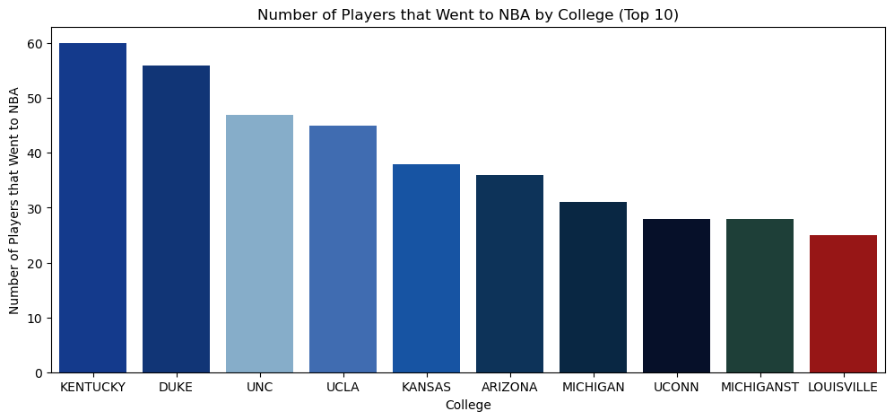

```python
non_duplicate_df = final_df.drop_duplicates(subset=['name', 'college_id', 'g'], keep='first')

palette = {
    'KENTUCKY': '#0033A0',
    'DUKE': '#003087',
    'UNC': '#7BAFD4',
    'UCLA': '#2D68C4',
    'KANSAS': '#0051BA',
    'ARIZONA': '#003366',
    'MICHIGAN': '#00274C',
    'UCONN': '#000E2F',
    'MICHIGANST': '#18453B',
    'LOUISVILLE': '#AD0000',
}

plt.rc("figure", figsize=(12,5))
college_counts = non_duplicate_df.groupby('college_id', as_index=False)['war_total_NBA'].agg(['size','mean'])
college_counts_top10 = college_counts.sort_values(by=['size'], ascending=False).head(10)
sns.barplot(x = 'college_id',y = 'size',data = college_counts_top10, palette=palette)
plt.xlabel('College')
plt.ylabel('Number of Players that Went to NBA')
plt.title('Number of Players that Went to NBA by College (Top 10)')
plt.show()
```

With common college basketball knowledge, this list is expected as the blue blood schools are the first 5 on this list. Now Lets look on how well these school's players performed in the NBA using WAR.

#### From those Top 10 Colleges, Lets How Well Their Players Performed in the NBA

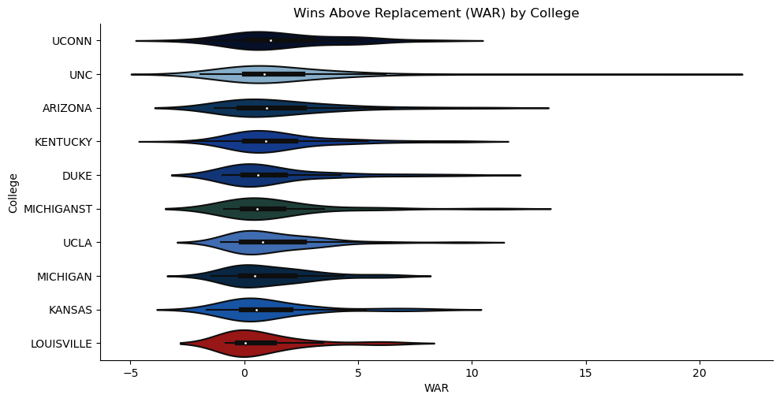

```python
violin_college = non_duplicate_df.loc[non_duplicate_df['college_id'].isin(college_counts_top10.college_id.unique())]
plt.rc("figure", figsize=(20,20))
order = violin_college.groupby('college_id')['war_total_NBA'].mean().sort_values(ascending=False).index
ax = sns.catplot(x="war_total_NBA", y="college_id", data=violin_college, aspect=2, kind="violin", order=order,palette=palette)
ax.set(ylabel='College',
       xlabel='WAR',
       title='Wins Above Replacement (WAR) by College')
plt.show()
```

This violin plot is sorted from top down by average WAR in the NBA. We can see UCONN leads this list, followed by North Carolina.

#### Wins Above Replacement by Decade Played and Position

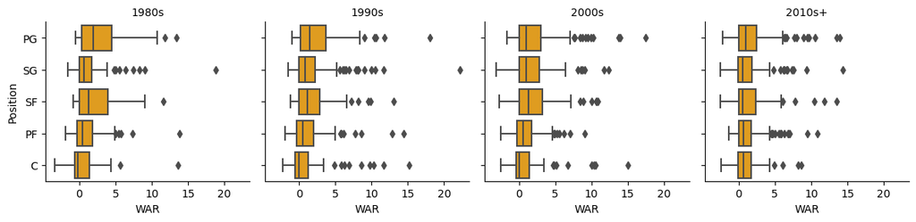

```python
import matplotlib.pyplot as plt
import seaborn as sns


plt.rc("figure", figsize=(50,30))
g = sns.FacetGrid(final_df, col="decade_NBA", col_order=['1980s', '1990s', '2000s', '2010s+'])
g.map(sns.boxplot, "war_total_NBA", "position", order=['PG', 'SG', 'SF', 'PF', 'C'], color="orange")
g.set(ylabel='Position',
       xlabel='WAR')
g.set_titles("{col_name}")
plt.show()
```

Looking at the plots we can see that in the 1980s and 1990s the point guard contributed the most. But in the 2000s and 2010s+, the box plots begin to level out and all positions contribute the same.

#### Top 15 NBA Players Based on Wins Above Replacement

```python
pd.set_option('display.max_rows', 15)
top15_df = final_df[['name','decade_NBA','war_total_NBA']].sort_values(by=['war_total_NBA'], ascending=False).head(15).reset_index()
top15_df.drop(['index'], axis=1, inplace=False)
```

[output not shown]

#### View the Distribution of our Independent and Dependent Variables

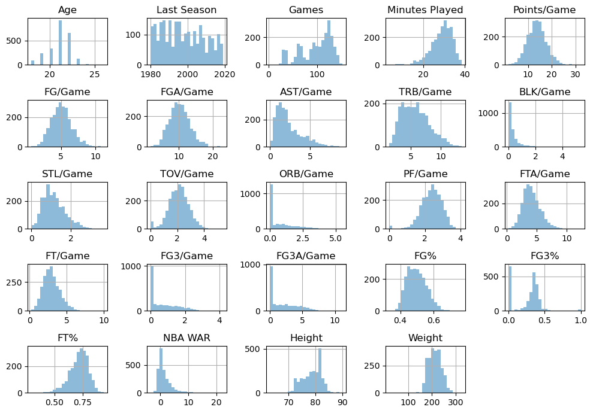

```python
# Show distribution of main predictors
import matplotlib.pyplot as plt
df_hist_predictors = final_df.drop(columns=['name', 'college_id'], inplace=False)
df_hist_predictors = df_hist_predictors.set_axis(['Age', 'Last Season', 'Games', 'Minutes Played', 'Points/Game', 'FG/Game', 'FGA/Game', 'AST/Game', 'TRB/Game', 'BLK/Game',
                                                 'STL/Game', 'TOV/Game', 'ORB/Game', 'PF/Game', 'FTA/Game', 'FT/Game', 'FG3/Game', 'FG3A/Game', 'FG%', 'FG3%', 'FT%', 'NBA Decade',
                                                 'NBA WAR', 'Position', 'Height', 'Weight'], axis=1)

df_hist_predictors.hist(bins=24, figsize=(10, 7), alpha=0.5)
plt.tight_layout()
plt.show()
```

Giving a look at these variables and their skewed distributions. We will look at normalizing each predictor before the modeling process.

#### View a Correlation Matrix

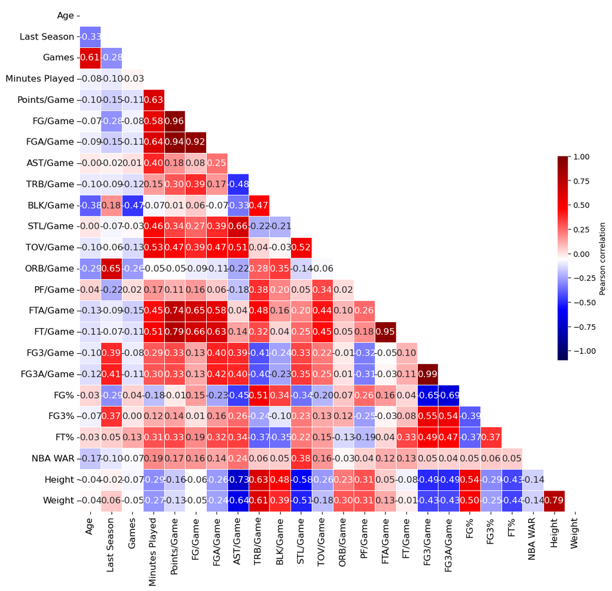

```python
df_corr = final_df.drop(columns=['name', 'position','college_id', 'decade_NBA'], inplace=False)
df_corr = df_corr.set_axis(['Age', 'Last Season', 'Games', 'Minutes Played', 'Points/Game', 'FG/Game', 'FGA/Game', 'AST/Game', 'TRB/Game', 'BLK/Game',
                                                 'STL/Game', 'TOV/Game', 'ORB/Game', 'PF/Game', 'FTA/Game', 'FT/Game', 'FG3/Game', 'FG3A/Game', 'FG%', 'FG3%', 'FT%',
                                                 'NBA WAR', 'Height', 'Weight'], axis=1)

corrmat = df_corr.corr()

# Set up the matplotlib figure
f, ax = plt.subplots(figsize=(12, 11))
ax = sns.heatmap(corrmat, mask=np.triu(np.ones(corrmat.shape)).astype(bool),
                 cmap='seismic', vmax=-1, vmin=1,
                 annot=True, annot_kws={'size': 12.0},
                 fmt='.2f', square=True, linewidths=.5,
                 cbar_kws={'shrink': 0.4, 'pad': -0.05})

# Colorbar
cbar = ax.collections[0].colorbar
cbar.set_label(label='Pearson correlation',size=10)
cbar.ax.tick_params(labelsize=10)
cbar.solids.set_edgecolor("face")

# Ticks
plt.xticks(rotation=90)
plt.yticks(rotation=0)
plt.tick_params(axis='both', labelsize=12)
plt.tight_layout()
plt.show()
```

We have a couple of highly correlated variables. College points per game is highly correlated with field goals made per game and field goals attempted per game. Field goals made per game and field goals attempted per game are also highly correlated. Given this we can remove both field goals made per game and field goals attempted per game. Free throws attempts per game and free throws made per game are highly correlated, we can remove both. Finally, three pointers made per game and three pointers attempted per game are highly correlated, so we can also remove those.

# 8 - Modeling Process

Our modeling process will have two parts to it.

Part 1 - This part we will split up the data into its respective decades at which the players played in. Then we will run a Linear Regression on the full dataset and extract the coefficients to analyze feature importance between the decades.

Part 2 - This part we will only use the dataset containing the most recent players. So, this means the player would have had to play his last college season in the 2010s and have played at least 600 minutes in the NBA during the 2010s. Then we will be comparing six models to find which is the best model through metrics like Mean Absolute Error (MAE), Mean Squared Error (MSE), and Root Mean Squared Error (RMSE). The models we will compare are Linear Regression, Elastic Net, Decision Tree Regressor, ADA Boost Regressor, Gradient Boost Regressor, and XGB Boost Regressor.

#### More Pre-Processing

We have some clean up to do with our data. First we drop the 'name' column because it isn't going to be useful in our predictions. Next, we drop our highly correlated variables Free Throw Attempts per Game, Free Throws per Game, Three-Pointers Made per Game, Three-Pointer Attempts per Game, Field Goals per Game, and Field Goals Attempted per Game. Then, we drop our College column, this is because there are too many colleges/categories to bin/encode, therefore I remove the column from the set of predictors. With more time and college basketball domain knowledge, I could probably find a way to drop the number of categories in the college column (e.g. something like good or bad basketball school). Finally, we transform our predictors, scaling the numeric predictors and One-Hot encode our only categorical predictor which is player position.

```python
from sklearn.model_selection import GridSearchCV, train_test_split, RepeatedKFold
from sklearn.pipeline import Pipeline
from sklearn.preprocessing import StandardScaler, OneHotEncoder, OrdinalEncoder
from sklearn.compose import ColumnTransformer

# Drop unique indentifiers in the dataset
df1 = final_df.drop(['name'], axis=1, inplace=False)

# Drop Highly Correlated Variables
df1 = df1.drop(['fta_game', 'ft_game', 'fg3_game', 'fg3a_game', 'fg_game', 'fga_game'], axis=1, inplace=False)

# Drop College Column
df1 = df1.drop(['college_id'], axis=1, inplace=False)

# https://stackoverflow.com/questions/54160370/how-to-use-sklearn-column-transformer

# Get all columns that we will scale and create pipeline for them
numeric_features = ['height', 'weight', 'age', 'g', 'mp_game',
                   'pts_game', 'ast_game', 'trb_game', 'blk_game', 'stl_game', 'tov_game', 'orb_game',
                   'pf_game', 'fg_perc', 'fg3_perc', 'ft_perc']
numeric_transformer = Pipeline(steps=[
    ('scaler', StandardScaler())])

# Get all columns that we will one hot encode and create pipeline for them
onehot_features = ['position']
onehot_transformer = Pipeline(steps=[
    ('onehot', OneHotEncoder())])

# Get all pipelines together in a column transformer object so we can use in our main model pipeline
preprocessor = ColumnTransformer(
    transformers=[
        ('num', numeric_transformer, numeric_features),
        ('onehot', onehot_transformer, onehot_features)], remainder='passthrough')
```

#### Splitting our Data into their Respective Decades and Analyzing

First, We split our data into their respective decades

```python
decade_80s = df1[df1['decade_NBA']=='1980s'].drop(['decade_NBA'], axis=1, inplace=False)
decade_90s = df1[df1['decade_NBA']=='1990s'].drop(['decade_NBA'], axis=1, inplace=False)
decade_00s = df1[df1['decade_NBA']=='2000s'].drop(['decade_NBA'], axis=1, inplace=False)
decade_10s = df1[df1['decade_NBA']=='2010s+'].drop(['decade_NBA'], axis=1, inplace=False)
```

Next, We create Linear Regression Models for all 4 decades and fit onto each dataset

```python
from sklearn.linear_model import LinearRegression

linear_80s = Pipeline(steps=[('preprocessor', preprocessor), ('linear', LinearRegression())])
linear_90s = Pipeline(steps=[('preprocessor', preprocessor), ('linear', LinearRegression())])
linear_00s = Pipeline(steps=[('preprocessor', preprocessor), ('linear', LinearRegression())])
linear_10s = Pipeline(steps=[('preprocessor', preprocessor), ('linear', LinearRegression())])

linear_80s.fit(decade_80s.loc[:, decade_80s.columns!='war_total_NBA'], decade_80s.loc[:, decade_80s.columns=='war_total_NBA'])
linear_90s.fit(decade_90s.loc[:, decade_90s.columns!='war_total_NBA'], decade_90s.loc[:, decade_90s.columns=='war_total_NBA'])
linear_00s.fit(decade_00s.loc[:, decade_00s.columns!='war_total_NBA'], decade_00s.loc[:, decade_00s.columns=='war_total_NBA'])
linear_10s.fit(decade_10s.loc[:, decade_10s.columns!='war_total_NBA'], decade_10s.loc[:, decade_10s.columns=='war_total_NBA'])

print()
```

Next, We create dataframes for each dataset with their feature importance. We will take the Top 8 features in magnitude to visualize.

```python
df_80s = pd.DataFrame({'Feature': ['Height', 'Weight', 'Age', 'Games', 'Minutes/Game', 'Pts/Game', 'Ast/Game', 'Reb/Game', 'Block/Game',
                                   'Steal/Game', 'TOV/Game', 'OREB/Game', 'PF/Game', 'FG%', 'FG3%', 'FT%',  'Is Center',
                                   'Is PF', 'Is PG', 'Is SF', 'Is SG', 'Last Season'],
                       'Coef': linear_80s['linear'].coef_[0]})
df_80s['Coef Mag'] = abs(df_80s['Coef'])
df_80s = df_80s.sort_values(by=['Coef Mag'], ascending=False).head(8)


df_90s = pd.DataFrame({'Feature': ['Height', 'Weight', 'Age', 'Games', 'Minutes/Game', 'Pts/Game', 'Ast/Game', 'Reb/Game', 'Block/Game',
                                   'Steal/Game', 'TOV/Game', 'OREB/Game', 'PF/Game', 'FG%', 'FG3%', 'FT%',  'Is Center',
                                   'Is PF', 'Is PG', 'Is SF', 'Is SG', 'Last Season'],
                       'Coef': linear_90s['linear'].coef_[0]})
df_90s['Coef Mag'] = abs(df_90s['Coef'])
df_90s = df_90s.sort_values(by=['Coef Mag'], ascending=False).head(8)


df_00s = pd.DataFrame({'Feature': ['Height', 'Weight', 'Age', 'Games', 'Minutes/Game', 'Pts/Game', 'Ast/Game', 'Reb/Game', 'Block/Game',
                                   'Steal/Game', 'TOV/Game', 'OREB/Game', 'PF/Game', 'FG%', 'FG3%', 'FT%',  'Is Center',
                                   'Is PF', 'Is PG', 'Is SF', 'Is SG', 'Last Season'],
                       'Coef': linear_00s['linear'].coef_[0]})
df_00s['Coef Mag'] = abs(df_00s['Coef'])
df_00s = df_00s.sort_values(by=['Coef Mag'], ascending=False).head(8)


df_10s = pd.DataFrame({'Feature': ['Height', 'Weight', 'Age', 'Games', 'Minutes/Game', 'Pts/Game', 'Ast/Game', 'Reb/Game', 'Block/Game',
                                   'Steal/Game', 'TOV/Game', 'OREB/Game', 'PF/Game', 'FG%', 'FG3%', 'FT%',  'Is Center',
                                   'Is PF', 'Is PG', 'Is SF', 'Is SG', 'Last Season'],
                       'Coef': linear_10s['linear'].coef_[0]})
df_10s['Coef Mag'] = abs(df_10s['Coef'])
df_10s = df_10s.sort_values(by=['Coef Mag'], ascending=False).head(8)
```

#### 1980s Feature Importance

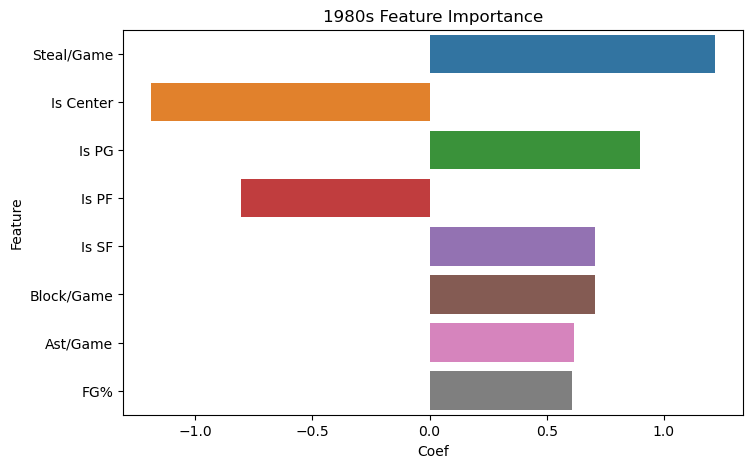

```python
plt.rc("figure", figsize=(8,5))
sns.barplot(df_80s, x="Coef", y="Feature", orient="h").set(title="1980s Feature Importance")
plt.show()
```

We can see that steals per game had the largest magnitude in coefficient and was positive. We can also see that being a big man (PF or C) negatively impacted a player’s Wins Above Average (WAR) in the NBA, whilst PG and SF positively impacted a player's WAR in the NBA.

#### 1990s Feature Importance

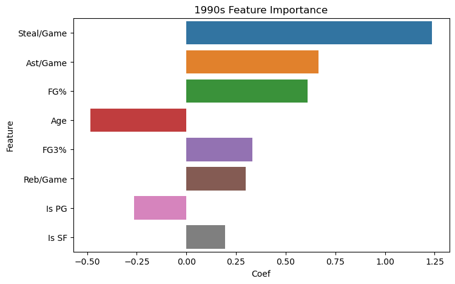

```python
plt.rc("figure", figsize=(8,5))
sns.barplot(df_90s, x="Coef", y="Feature", orient="h").set(title="1990s Feature Importance")
plt.show()
```

We can see again that steals per game had the largest magnitude in coefficient and was positive. Also assists per game and FG percentage positively impacted WAR. Different from the 1980s decade, being a PG and the age, the player left college also negatively impacted WAR. Also, we can see Three Points %, this isn’t a surprise as the three-point line got introduced in the NBA in 1984.

#### 2000s Feature Importance

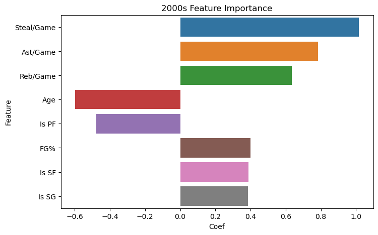

```python
plt.rc("figure", figsize=(8,5))
sns.barplot(df_00s, x="Coef", y="Feature", orient="h").set(title="2000s Feature Importance")
plt.show()
```

We can see again that steals per game had the largest magnitude in coefficient and was positive. Also, assists per game and rebounds per game positively impacted WAR. Again, the age the player left college and being a PF negatively impacted WAR.

#### 2010s Feature Importance

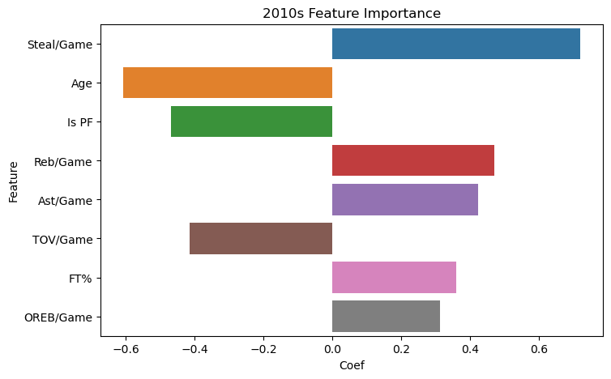

```python
plt.rc("figure", figsize=(8,5))
sns.barplot(df_10s, x="Coef", y="Feature", orient="h").set(title="2010s Feature Importance")
plt.show()
```

We can see again that steals per game had the largest magnitude in coefficient and was positive. Again, assists per game and rebounds per game positively impacted WAR. The age the player left college and being a PF negatively impacted WAR. Also, Turnovers per game made an appearance negatively impacting WAR. On top of that, Free Throw Percentage and Offensive Rebounds per Game made their first appearance positively impacting WAR.

#### Train/Test Split and Repeated Cross-Validation with our 2010s Data

Now, we would like to create a model that could accurately predict today’s prospect. So, the best dataset to do this on is our most recent decade dataset which is the 2010s+ dataset.

We do one little pre-processing before the modeling process. Originally our dataset only included players that have played in the 2010s, meaning these players could’ve graduated college in the 1990s or 2000s. Since we don’t want to run a model on players that played college in previous decades because not only has the NBA changed through decades, so has college. Given this, we will only include players that played their last season in the 2010s decade, which should give our models the most accurate landscape of college basketball. We also get rid of the Year the Player left college predictor.

For the actual modeling process we will do a 75% to 25% train to test split and perform Repeated K-Fold Cross-Validation when parameter tuning where we have 5 folds and repeat it 3 times.

We will compare six models, which are Linear Regression, Elastic Net, Decision Tree, ADA Boost, Gradient Boost, and XG Boost.

```python
from sklearn.model_selection import train_test_split

decade_data = decade_10s[decade_10s['end_season'] >= 2010].drop(['end_season'], axis=1, inplace=False)

X_train, X_test, y_train, y_test = train_test_split(decade_data.loc[:, decade_data.columns!='war_total_NBA'], decade_data.loc[:, decade_data.columns=='war_total_NBA'],
                                                    test_size=0.25, random_state=11)
```

```python
cv = RepeatedKFold(n_splits=5, n_repeats=3, random_state=7) # Repeated K-Fold Cross-Validation
```

#### Linear Regression

```python
from sklearn.linear_model import LinearRegression

# Pipeline for Linear Regression
pipe_linear = Pipeline(steps=[('preprocessor', preprocessor),
                               ('linear', LinearRegression())])

# Fit Linear Regression on training dataset
pipe_linear.fit(X_train, y_train)
y_pred_linear = pipe_linear.predict(X_test) # Predict on test set
```

#### Elastic Net

```python
from sklearn.linear_model import ElasticNet

# Pipeline for Elastic Net
pipe_enet = Pipeline(steps=[('preprocessor', preprocessor),
                             ('enet', ElasticNet(random_state=7))])

# Tuning parameters for Elastic Net
tune_enet = [{'enet__alpha':[0.00005,0.0005,0.001, 0.01, 0.05, 0.08, 1, 5, 10, 50, 100],
              'enet__l1_ratio':[.00001,.0001,.001,.01,0.1,0.5,1]}]

# Grid Search parameter tuning for Elastic Net
enet_regression = GridSearchCV(pipe_enet, tune_enet, cv=cv, scoring='neg_mean_squared_error', refit=True)

enet_regression.fit(X_train, y_train) # Fit on Training dataset
#print("Best Parameters: ", enet_regression.best_params_) # Get best parameters
y_pred_enet = enet_regression.predict(X_test) # Predict on test set
```

#### Decision Tree Regressor

```python
from sklearn.tree import DecisionTreeRegressor

# Pipeline for Decision Tree Regressor
pipe_dt = Pipeline(steps=[('preprocessor', preprocessor),
                          ('dt', DecisionTreeRegressor(random_state=7))])

# Tuning parameters Decision Tree Regressor
tune_dt = [{
  'dt__ccp_alpha': [.001,.01,.1,.5,1],
  'dt__max_depth': [None,1,3,5],
}]

# Grid Search parameter tuning for Decision Tree Regressor
dt_regression = GridSearchCV(pipe_dt, tune_dt, cv=cv, scoring='neg_mean_squared_error', refit=True)

dt_regression.fit(X_train, y_train) # Fit on Training dataset
#print("Best Parameters: ", dt_regression.best_params_) # Get best parameters
y_pred_dt = dt_regression.predict(X_test) # Predict on test set
```

#### ADA Boost Regressor

```python
from sklearn.ensemble import AdaBoostRegressor

# Pipeline for AD Boost Regressor
pipe_ada = Pipeline(steps=[('preprocessor', preprocessor),
                          ('ada', AdaBoostRegressor(random_state=7))])

# Tuning parameters AD Boost Regressor
tune_ada = [{"ada__n_estimators": [10, 50, 100],
             "ada__learning_rate": [.001, .01,.1, .5]}]

# Grid Search parameter tuning for AD Boost Regressor
ada_regression = GridSearchCV(pipe_ada, tune_ada, cv=cv, scoring='neg_mean_squared_error', refit=True)

ada_regression.fit(X_train, y_train) # Fit on Training dataset
#print("Best Parameters: ", ada_regression.best_params_) # Get best parameters
y_pred_ada = ada_regression.predict(X_test) # Predict on test set
```

#### Gradient Boost Regressor

```python
from sklearn.ensemble import GradientBoostingRegressor

# Pipeline for Gradient Boost Regressor
pipe_gb = Pipeline(steps=[('preprocessor', preprocessor),
                          ('gb', GradientBoostingRegressor(random_state=7))])

# Tuning parameters Gradient Boost Regressor
tune_gb = [{"gb__n_estimators": [5 ,10, 50, 100],
             "gb__learning_rate": [.001,.01,.1,.5]}]

# Grid Search parameter tuning for Gradient Boost Regressor
gb_regression = GridSearchCV(pipe_gb, tune_gb, cv=cv, scoring='neg_mean_squared_error', refit=True)

gb_regression.fit(X_train, y_train) # Fit on Training dataset
#print("Best Parameters: ", gb_regression.best_params_) # Get best parameters
y_pred_gb = gb_regression.predict(X_test) # Predict on test set
```

#### XGB Boost Regressor

```python
from xgboost import XGBRegressor

# Pipeline for XG Boost Regressor
pipe_xgb = Pipeline(steps=[('preprocessor', preprocessor),
                          ('xgb', XGBRegressor(random_state=7, objective ='reg:squarederror'))])

# Tuning parameters XG Boost Regressor
tune_xgb = [{
  'xgb__max_depth': [2,3,4,5],
  'xgb__alpha': [.1,1,10,50],
  'xgb__learning_rate': [.01, .1, 1],
  'xgb__n_estimators': [10, 100, 200]
}]

# Grid Search parameter tuning for XG Boost Regressor
xgb_regression = GridSearchCV(pipe_xgb, tune_xgb, cv=cv, scoring='neg_mean_squared_error', refit=True)

xgb_regression.fit(X_train, y_train) # Fit on Training dataset
#print("Best Parameters: ", xgb_regression.best_params_) # Get best parameters
y_pred_xgb = xgb_regression.predict(X_test) # Predict on test set
```

# 9 - Model Results

```python
from sklearn.metrics import mean_squared_error, mean_absolute_error
from math import sqrt

# Gather all results for dataframe
data1 = {'Model': ['Linear Regression', 'Elastic Net', 'Decision Tree', 'ADA Boost', 'Gradient Booster', 'XG Boost'],
         'MSE': [mean_squared_error(y_test, y_pred_linear), mean_squared_error(y_test, y_pred_enet), mean_squared_error(y_test, y_pred_dt), mean_squared_error(y_test, y_pred_ada),
                 mean_squared_error(y_test, y_pred_gb), mean_squared_error(y_test, y_pred_xgb)],
         'RMSE': [sqrt(mean_squared_error(y_test, y_pred_linear)), sqrt(mean_squared_error(y_test, y_pred_enet)), sqrt(mean_squared_error(y_test, y_pred_dt)), sqrt(mean_squared_error(y_test, y_pred_ada)),
                 sqrt(mean_squared_error(y_test, y_pred_gb)), sqrt(mean_squared_error(y_test, y_pred_xgb))],
         'MAE': [mean_absolute_error(y_test, y_pred_linear), mean_absolute_error(y_test, y_pred_enet), mean_absolute_error(y_test, y_pred_dt), mean_absolute_error(y_test, y_pred_ada),
                 mean_absolute_error(y_test, y_pred_gb), mean_absolute_error(y_test, y_pred_xgb)]}

# Create and show dataframe
result_df = pd.DataFrame(data1) # Dataframe to show results
result_df
```

|  | Model | MSE | RMSE | MAE |
| --- | --- | --- | --- | --- |
| 0 | Linear Regression | 2.317561 | 1.522354 | 1.157951 |
| 1 | Elastic Net | 2.175833 | 1.475071 | 1.105586 |
| 2 | Decision Tree | 2.462129 | 1.569117 | 1.209767 |
| 3 | ADA Boost | 2.203166 | 1.484307 | 1.154679 |
| 4 | Gradient Booster | 2.227558 | 1.492501 | 1.144477 |
| 5 | XG Boost | 2.132500 | 1.460308 | 1.080063 |

#### Model Conclusion

We will judge the best model by which model has the best Mean Squared Error (MSE), Root Mean Squared Error (RMSE), and Mean Absolute Error (MAE). Given the Criteria, XG Boost has the smallest/best value for MSE, RMSE, and MAE with an MSE of 2.13, an RMSE of 1.46, and an MAE of 1.08. Given this, we would deem the XG Boost as our best model.

#### XG Boost Coefficients

```python
xgb_df = pd.DataFrame({'Feature': ['Height', 'Weight', 'Age', 'Games', 'Minutes/Game', 'Pts/Game', 'Ast/Game', 'Reb/Game', 'Block/Game',
                                   'Steal/Game', 'TOV/Game', 'OREB/Game', 'PF/Game', 'FG%', 'FG3%', 'FT%',  'Is Center',
                                   'Is PF', 'Is PG', 'Is SF', 'Is SG',],
                       'Coef': xgb_regression.best_estimator_['xgb'].feature_importances_})
xgb_df['Coef Mag'] = abs(xgb_df['Coef'])
xgb_df = xgb_df.sort_values(by=['Coef Mag'], ascending=False)
```

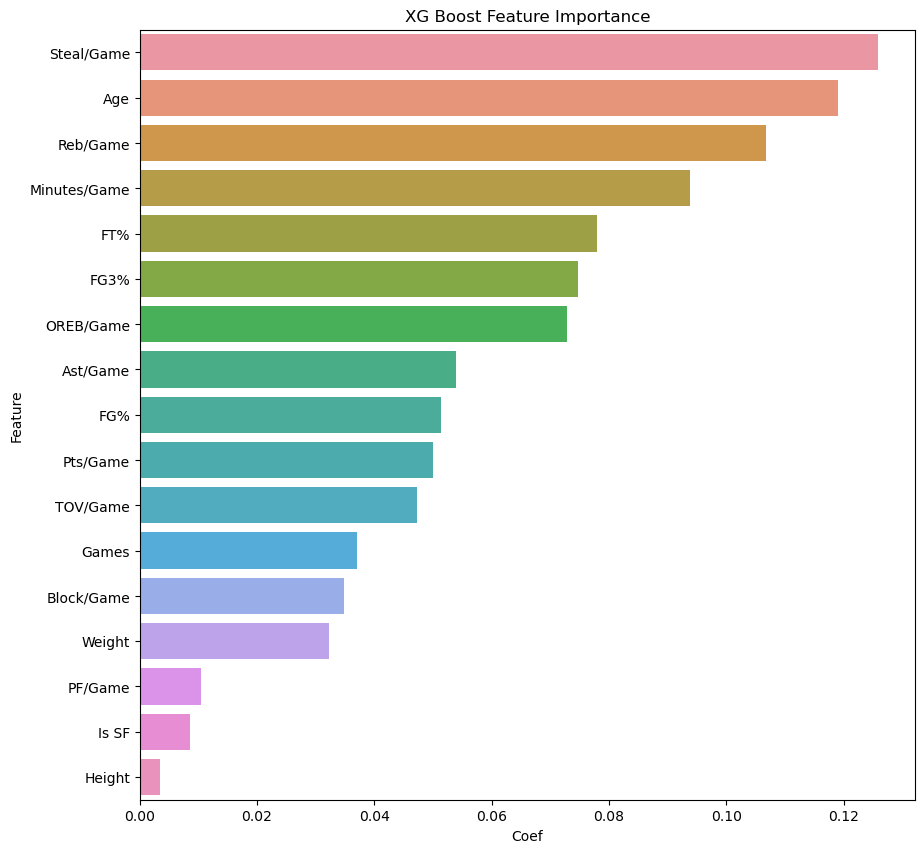

```python
plt.rc("figure", figsize=(10,10))
sns.barplot(xgb_df[xgb_df['Coef'] != 0], x="Coef", y="Feature", orient="h").set(title='XG Boost Feature Importance')
plt.show()
```

We can see that again, Steals Per Game has the most importance along with Age. A couple of other important features were Rebounds per Game, Minutes Played per Game, Free Throw Percentage, and Three Point Percentage.

We can also notice we are missing a few predictors. Here we are missing whether the player was a Power Forward, Point Guard, Center, or Shooting Guard. Our XG Boost model gave these four predictors a coefficient of 0.

#### Comparing The Top 15 Players in WAR with Their Steals Per Game in College

```python
pd.set_option('display.max_rows', 15)
top15_df_steal = final_df[['name','decade_NBA','war_total_NBA','stl_game']].sort_values(by=['war_total_NBA'], ascending=False).head(15).reset_index()
top15_df_steal.drop(['index'], axis=1, inplace=False)
```

|  | name | decade_NBA | war_total_NBA | stl_game |
| --- | --- | --- | --- | --- |
| 0 | Michael Jordan | 1990s | 22.228866 | 1.673267 |
| 1 | Michael Jordan | 1980s | 18.825433 | 1.673267 |
| 2 | John Stockton | 1990s | 18.060982 | 2.448598 |
| 3 | Chris Paul | 2000s | 17.447706 | 2.539683 |
| 4 | David Robinson | 1990s | 15.211551 | 1.259843 |
| 5 | Tim Duncan | 2000s | 15.016748 | 0.539062 |
| 6 | Karl Malone | 1990s | 14.376865 | 1.641304 |
| 7 | James Harden | 2010s+ | 14.351056 | 1.913043 |
| 8 | Jason Kidd | 2000s | 13.946702 | 3.457627 |
| 9 | Chris Paul | 2010s+ | 13.936223 | 2.539683 |
| 10 | Charles Barkley | 1980s | 13.822045 | 0.904762 |
| 11 | John Stockton | 2000s | 13.772485 | 2.448598 |
| 12 | Hakeem Olajuwon | 1980s | 13.611815 | 1.340000 |
| 13 | Stephen Curry | 2010s+ | 13.487678 | 2.125000 |
| 14 | Kevin Durant | 2010s+ | 13.467645 | 1.885714 |

Looking at the the table, we can see the majority of the players have a high value of steals per game. For reference the average steals per game sits just above 1.0 steals per game. We can see a lot of players average over 2 steals per game, almost doubled from the average.

# 10 - Final Conclusion

#### Limitations

To start, the selection of the outcome variable or what we measured as NBA success (Wins Above Replacement (WAR)) is subjective. Meaning other individuals might say NBA Points per Game or Number of Championships won could replace WAR for the metric that determines NBA Success.

In this project we chose average WAR over a decade as our outcome variable. Now, there could be issues where a player only played 3 games in a season where he didn’t play well those 3 games and this would negatively impact his average WAR across that decade. Other alternatives could’ve been total WAR across the decade or prorated the WAR for a player in the season to reflect 82 games then take the average across the decade.

Lastly, the college team column. Now the college team the player played on influences how well the player played in college. For example, a team like Duke will have a team with multiple players that could go to the NBA, meaning these players will need to take a step back in production to let the other players' shine. Like mentioned before I would like to figure out a way to split the college team column into something like good, average, or bad school.

#### Conclusion

In conclusion, from our decade analysis we saw a player’s Steals per Game in college was a large positive influence on the player’s NBA Wins Above Average (WAR). From our modeling process with our 2010s+ only dataset, we were able to obtain a MSE of 2.133, an RMSE of 1.460, and an MAE of 1.080 from our best model which was XG Boost. Just like from the decade analysis, we saw that a player’s Steals per Game in college had the highest importance towards that player’s NBA WAR in our XG Boost Model.

We also saw that our XG Boost Model gave whether the player was a Small Forward a low coefficient and gave whether the player was a Point Guard, Shooting Guard, Power Forward, or Center a coefficient of 0. This goes with our previous claim and current trends of the NBA that the NBA is positionless.

#### Future Considerations

For starters, we could spend more time tuning our XG Boost model to get a better result.

We could also take previous NBA Draft classes and run our model on these player’s college statistics. Then give each player drafted a rank based on their NBA Wins Above Average (WAR) from our model, then compare it to the actual rank/spot they got drafted.

We could tweak our model to be able to take a player’s college stats and predict their WAR over the course of a 20 year span. This could show the trends of what year a player might break out and become a star or see when that player’s performance might start declining. This would influence contract signings and extensions.

# References

Berger T, Daumann F. Anchoring bias in the evaluation of basketball players: A closer look at NBA draft decision-making. Manage Decis Econ. 2021; 42: 1248–1262. https://doi.org/10.1002/mde.3305

Bishop, Ethan. "The Journey from College Basketball to the NBA: Key Differences and Challenges." Sportskeeda, 9 May 2023, www.sportskeeda.com/basketball/the-journey-college-basketball-nba-key-differences-challenges.

Iyer, Visalakshi; 2022; NBA Evaluation of Players by RAPTOR; Kaggle. https://www.kaggle.com/datasets/visalakshiiyer/nba-match-data.

NBA.com Staff. "2024 NBA Draft Lottery: Odds, History and How It Works." NBA, 31 Jan. 2024, www.nba.com/news/nba-draft-lottery-explainer.

NBA, & NBPA. (2023). Collective bargaining agreement 2023. Retrieved from: https://nbpa.com/cba

Tan, Calvin; 2023; College game statistics of NBA players; Kaggle. https://www.kaggle.com/datasets/calvintancy/college-game-statistics-of-nba-players.